# Final Project

Elizabeth Faragi

```r
library(tidyverse)
library(readr)
```

Here, I am loading up the tidyverse and readr to allow myself to analyze the data correctly.

```r
nfl_attendance_25 <- read_csv("https://docs.google.com/spreadsheets/d/e/2PACX-1vSbp3ApjVnRb1Hn5ZvAljgdUfAo_9h2SUpMDpWohkibZFXXuxdfflDqhQNo8bDv6T6bvagd9ElXe8Tq/pub?gid=1860385982&single=true&output=csv")

nfl_attendance_24 <- read_csv("https://docs.google.com/spreadsheets/d/e/2PACX-1vTJD4pEJMx2E6ZwgRGAOYgzLA-hlPgi4ncAIChFKTQqj2VQXNB0GHH5WW4JIY2ty7pCMCKgyKd8yvp9/pub?gid=1809535861&single=true&output=csv")

nfl_attendance_23 <- read_csv("https://docs.google.com/spreadsheets/d/e/2PACX-1vSH4DJykatnnOPVRRNaXXDFbayGwSzdBe0E9WCOO2cVaeyYDibp1tBNWHLS-1E0EcNl8Su5W3LzNf6A/pub?gid=1071365491&single=true&output=csv")

nfl_attendance_22 <- read_csv("https://docs.google.com/spreadsheets/d/e/2PACX-1vSMGvArhs4WtmqIPFdiikCpZzk4JqOGGEP8IZzgUdxw-qld5K2qRJWOVE-lNn7KbeOQC-bx9a9MV40j/pub?gid=1753832751&single=true&output=csv")

nfl_attendance_21 <- read_csv("https://docs.google.com/spreadsheets/d/e/2PACX-1vS5iE43Sg9njlwgoYc1zJuHyI9rFbh6BgSpU2KbE0XW4TWwBcba2vCSueIeed9iZH5Ozu8Ig8hxyBub/pub?gid=1772701353&single=true&output=csv")

nfl_attendance_20 <- read_csv("https://docs.google.com/spreadsheets/d/e/2PACX-1vSXKYT-bUHh6v_LABNbyv1rKUuWKGeCvyQxlYkn321fwUA-LP4ITAbsFww5DYS5Z1eP9K9j2X1nTufC/pub?gid=1406948821&single=true&output=csv")

nfl_attendance_19 <- read_csv("https://docs.google.com/spreadsheets/d/e/2PACX-1vQhQ2wVYW5tjnMFhRQPAPHODZwFi2JItJy2D9W7pHurmpFQCLdw15rjYJ5_Cv3fJLm6DvnAztX-87k7/pub?gid=879147847&single=true&output=csv")

nfl_attendance_18 <- read_csv("https://docs.google.com/spreadsheets/d/e/2PACX-1vSKFNWmcoUaCL0jYn54Ayf8UGxJ5R3qMAxXebDN_XyIa0QolvsP6cepJHFhK9CPmjjU36THHwxiAosZ/pub?gid=1396054314&single=true&output=csv")

nfl_attendance_17 <- read_csv("https://docs.google.com/spreadsheets/d/e/2PACX-1vThICcScQU8VsKd_U2rV9hJlmpxUAmoA_Cs4zGtzrWH8kPZV_BrnieixrSyW4XYDfF6h8yWDP4M_LHV/pub?output=csv")

nfl_attendance_16 <- read_csv("https://docs.google.com/spreadsheets/d/e/2PACX-1vSGzNDmciJOvJNuIhpIuO55_LUlphWq6Pq-bSORV-MDPQjKA-3sjRgo4hRYP01Z_31rz6tpqBUIgk1x/pub?gid=51438010&single=true&output=csv")

nfl_attendance_15 <- read_csv("https://docs.google.com/spreadsheets/d/e/2PACX-1vTJcopswsvGlddmiOCN63p_OCuJcGWjcYg4wbVRNVwc_8lu7NSU-vHdI0vO9FGFMwqfH8LEFzibPo3F/pub?gid=962935019&single=true&output=csv")
```

Here, I loaded up all my data from published spreadsheets I created. The data includes weekly attendance to NFL stadiums from 2015 to 2025. Each spreadsheet has the attendance to each stadium by week for each season.

```r
nfl_attendance <- bind_rows(
 nfl_attendance_25 |> mutate(season = 2025) |> pivot_longer(starts_with("Week"),names_to = "week",values_to = "attendance",values_transform = list(attendance = as.character) ) |>mutate(attendance = parse_number(attendance)),
 nfl_attendance_24 |> mutate(season = 2024) |> pivot_longer(starts_with("Week"),names_to = "week",values_to = "attendance",values_transform = list(attendance = as.character) ) |>mutate(attendance = parse_number(attendance)),
 nfl_attendance_23 |> mutate(season = 2023) |> pivot_longer(starts_with("Week"),names_to = "week",values_to = "attendance",values_transform = list(attendance = as.character) ) |>mutate(attendance = parse_number(attendance)),
 nfl_attendance_22 |> mutate(season = 2022) |> pivot_longer(starts_with("Week"),names_to = "week",values_to = "attendance",values_transform = list(attendance = as.character) ) |>mutate(attendance = parse_number(attendance)),
 nfl_attendance_21 |> mutate(season = 2021) |> pivot_longer(starts_with("Week"),names_to = "week",values_to = "attendance",values_transform = list(attendance = as.character) ) |>mutate(attendance = parse_number(attendance)),
 nfl_attendance_20 |> mutate(season = 2020) |> pivot_longer(starts_with("Week"),names_to = "week",values_to = "attendance",values_transform = list(attendance = as.character) ) |>mutate(attendance = parse_number(attendance)),
 nfl_attendance_19 |> mutate(season = 2019) |> pivot_longer(starts_with("Week"),names_to = "week",values_to = "attendance",values_transform = list(attendance = as.character) ) |>mutate(attendance = parse_number(attendance)),
 nfl_attendance_18 |> mutate(season = 2018) |> pivot_longer(starts_with("Week"),names_to = "week",values_to = "attendance",values_transform = list(attendance = as.character) ) |>mutate(attendance = parse_number(attendance)),
 nfl_attendance_17 |> mutate(season = 2017) |> pivot_longer(starts_with("Week"),names_to = "week",values_to = "attendance",values_transform = list(attendance = as.character) ) |>mutate(attendance = parse_number(attendance)),
 nfl_attendance_16 |> mutate(season = 2016) |> pivot_longer(starts_with("Week"),names_to = "week",values_to = "attendance",values_transform = list(attendance = as.character) ) |>mutate(attendance = parse_number(attendance)),
 nfl_attendance_15 |> mutate(season = 2015) |> pivot_longer(starts_with("Week"),names_to = "week",values_to = "attendance",values_transform = list(attendance = as.character) ) |>mutate(attendance = parse_number(attendance))
) |> filter(!is.na(attendance))
```

```r
superbowl_winners <- tibble(
  Year = c(2025, 2024, 2023, 2022, 2021, 2020, 2019, 2018, 2017, 2016, 2015),  # season years
  winner = c("Philadelphia Eagles", "Kansas City Chiefs","Kansas City Chiefs", "Los Angeles Rams", "Tampa Bay Buccaneers", "Kansas City Chiefs", "New England Patriots", "Philadelphia Eagles", "New England Patriots","Denver Broncos","New England Patriots")
)

superbowl_winners <- superbowl_winners |>
  mutate(Year = as.numeric(Year))

nfl_attendance <- nfl_attendance |>
  mutate(season = as.numeric(season))

nfl_attendance <- nfl_attendance %>%
  left_join(superbowl_winners, by = c("season" = "Year"))
```

Here, I’m creating a table of the Superbowl winners by season. I then merged that table with the main nfl attendance data set so I can easily see all the data in one set.

```r
superbowl_winners <- superbowl_winners |>
  mutate(next_season = Year + 1)
```

This code creates a column for next_season, basically telling me which season they would be title holders.

```r
defending_champs <- superbowl_winners |>
  select(next_season, winner) |>
  rename(season = next_season, defending_champ = winner)
```

This creates a new data set called defending_champs that tells us for which season what team is the defending champ of the Superbowl. Basically, this will help me see what team won the Superbowl the year before, making them the defending champ for the next season.

```r
nfl_attendance <- nfl_attendance |>
  left_join(defending_champs, by = "season") |>
  mutate(is_defending_champ = Tm == defending_champ)
```

```r
team_season_avg <- nfl_attendance |>
  group_by(Tm, season) |>
  summarize(
    avg_attendance = mean(attendance, na.rm = TRUE),
    home_avg       = mean(attendance[str_detect(week, "Week")], na.rm = TRUE),
    is_defending_champ = any(is_defending_champ, na.rm = TRUE),
    .groups = "drop"
  )
```

This creates a data frame called team_season_avg that calculates the average stadium attendance for each team for each season. It also includes the home average for home games. It also adds the is_defending_champs column to this dataset, which makes it easier to see the average attendance of teams in comparison to whether or not they are the defending champs.

```r
team_season_avg <- team_season_avg |>
  arrange(Tm, season) |>
  group_by(Tm) |>
  mutate(
    prev_avg    = lag(avg_attendance),
    pct_change  = (avg_attendance - prev_avg) / prev_avg * 100
  ) |>
  ungroup()
```

This creates a column that includes the previous season’s average attendance and a column that calculates the percent change between the two. This helps show the difference in attendance from season to season. It also helps to see if being the defending champ changes attendance at all.

```r
team_season_clean <- team_season_avg |>
  filter(!season %in% c(2020, 2021), !is.na(pct_change))
```

This code cleans the data, accounting for COVID games because attendance is affected by COVID. This code excludes the COVID seasons to clean the data, because attendance was lower for COVID seasons and we don’t want that to affect our findings.

```r
champ_changes     <- team_season_clean |> filter(is_defending_champ == TRUE)  |> pull(pct_change)
non_champ_changes <- team_season_clean |> filter(is_defending_champ == FALSE) |> pull(pct_change)

cat("Defending champions — mean pct change:", round(mean(champ_changes), 2), "%\n")
```

```
Defending champions — mean pct change: -0.17 %
```

```r
cat("All other teams   — mean pct change:", round(mean(non_champ_changes), 2), "%\n")
```

```
All other teams   — mean pct change: 0.05 %
```

```r
cat("Number of defending-champion seasons:", length(champ_changes), "\n\n")
```

```
Number of defending-champion seasons: 8
```

```r
t.test(champ_changes, non_champ_changes)
```

```
    Welch Two Sample t-test

data:  champ_changes and non_champ_changes
t = -0.20382, df = 7.6345, p-value = 0.8438
alternative hypothesis: true difference in means is not equal to 0
95 percent confidence interval:
 -2.690278  2.256672
sample estimates:
  mean of x   mean of y
-0.17075770  0.04604532
```

This code runs a t-test comparing the differences in percent changes between teams who weren’t the defending champ and teams that were. It is testing whether or not being the Superbowl defending champ affects attendance at all. We see that, based on the p-value of 0.8, we cannot reject the null hypothesis. This means that we can’t determine from this data that being the Superbowl defending champions affects in-person game attendance for the season.

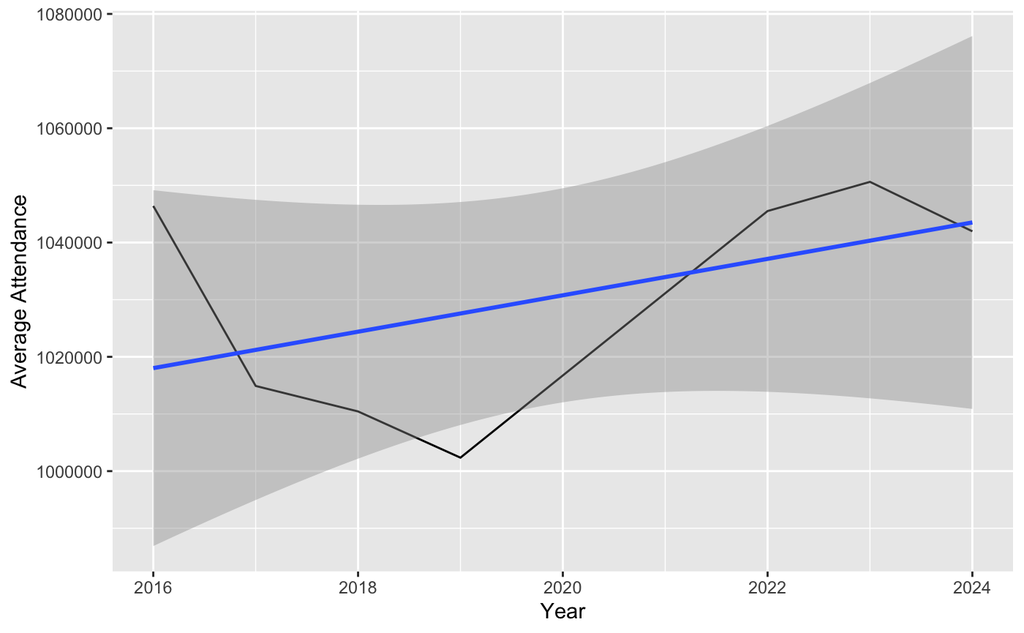

```r
year_by_year_league_wide <- team_season_clean |>
  filter(str_detect(team, "League Totals")) |>
  ggplot() +
  geom_line(aes(x=season, y=avg_attendance)) +
  geom_smooth(aes(x=season, y=avg_attendance), method="lm") +
  labs(
    x = "Year",
    y = "Average Attendance"
  )
year_by_year_league_wide
```

This code creates a line graph of the average attendance of in-person games year-by-year. We can see that, overall, attendance for all teams is going up since 2019, with a drop from 2023 to 2024. This graph shows why being the Superbowl defending champ might not affect attendance: all teams game attendance is going up, so being the defending champ isn’t going to affect much because as a whole, the NFL games are getting more popular.

However, our findings may suggest that NFL in-person attendance as a whole is going up. An interesting story pitch could use this data to determine if NFL in-person attendance has been going up and which teams have seen the biggest jump over the last 10 years. It could also be used to see which teams have seen a decrease in attendance. If we look at the percent change column in the team_season_avg dataframe, we can see some high positives, along with some high negatives. A cool data story could analyze which teams are seeing an increase and which are seeing a decrease, as well as if NFL attendance as a whole is increasing.

Further reporting could include analyzing ticket prices as well. Maybe the Buffalo Bills saw a 5.26% decrease in in-person attendance from 2016 to 2017 because their ticket prices went up. I’d also like to see if TV data could aid in determining whether or not being the Superbowl defending champ affects viewership. I was unable to find public TV data for NFL games, but if I could, I’d like to see if the defending champ team got more TV views throughout the season in comparison to other games. That could be an interesting story on whether or not Superbowl defending champ affects TV viewership and, furthermore, which teams get the most traction on TV. This could help TV stations decide which games they want to air to get the more action on their station.